# Lab 4: Childcare Costs in California

Author

Nathan Huang

## The Data

In this lab we’re going look at the median weekly cost of childcare in California. A detailed description of the data can be found [here](https://github.com/rfordatascience/tidytuesday/blob/master/data/2023/2023-05-09/readme.md).

The data come to us from [TidyTuesday](https://github.com/rfordatascience/tidytuesday).

**0. Load the appropriate libraries and the data.**

```r
library(tidyverse)
library(forcats)
```

```r
childcare_costs <- read_csv('https://raw.githubusercontent.com/rfordatascience/tidytuesday/master/data/2023/2023-05-09/childcare_costs.csv')
counties <- read_csv('https://raw.githubusercontent.com/rfordatascience/tidytuesday/master/data/2023/2023-05-09/counties.csv')
```

**1. Briefly describe the dataset (~ 4 sentences). What information does it contain?** The dataset contains data on income, employment, childcare costs and other data for each county. There are 2 files childcare_costs and counties linked by a country_fips_code. This allows us to analyze childcare cost across different places.

## California Childcare Costs

Let’s start by focusing only on California.

```r
ca_childcare <-
  childcare_costs|>
  inner_join(counties,
             by = join_by(county_fips_code == county_fips_code)) |>
  filter(state_name == "California" & state_abbreviation == "CA")
```

**3. Using a function from the `forcats` package, complete the code below to create a new variable where each county is categorized into one of the [10 Census regions](https://census.ca.gov/regions/) in California. Use the Region description (from the plot), not the Region number.**  
*Hint: This is probably a good place to use ChatGPT to reduce on tedious work. But you do need to know how to prompt ChatGPT to make it useful!*

```r
ca_childcare <- ca_childcare |>
  mutate(county_name = str_remove(county_name, " County")) |>
  mutate(census_region = fct_collapse(
    county_name,
    "Superior California" = c("Butte", "Colusa", "El Dorado", "Glenn", "Lassen", "Modoc", "Nevada",
                   "Placer", "Plumas", "Sacramento", "Shasta", "Sierra", "Siskiyou",
                   "Sutter", "Tehama", "Yolo", "Yuba"),
    "North Coast" = c("Del Norte", "Humboldt", "Lake", "Mendocino", "Napa", "Sonoma", "Trinity"),
    "San Francisco Bay Area" = c("Alameda", "Contra Costa", "Marin", "San Francisco", "San Mateo",
                   "Santa Clara", "Solano"),
    "Northern San Joaquin Valley" = c("Alpine", "Amador", "Calaveras", "Madera", "Mariposa", "Merced",
                   "Mono", "San Joaquin", "Stanislaus", "Tuolumne"),
    "Central Coast" = c("Monterey", "San Benito", "San Luis Obispo", "Santa Barbara",
                   "Santa Cruz", "Ventura"),
    "Southern San Joaquin Valley" = c("Fresno", "Inyo", "Kern", "Kings", "Tulare"),
    "Inland Empire" = c("Riverside", "San Bernardino"),
    "Los Angeles County" = c("Los Angeles"),
    "Orange County" = c("Orange"),
    "San Diego-Imperial" = c("Imperial", "San Diego")
  ))
ca_childcare
```

```
# A tibble: 638 × 65
   county_fips_code study_year unr_16 funr_16 munr_16 unr_20to64 funr_20to64
              <dbl>      <dbl>  <dbl>   <dbl>   <dbl>      <dbl>       <dbl>
 1             6001       2008   6.6     6.57    6.63        6.1         6.1
 2             6001       2009   7.71    7.53    7.86        7.2         7.1
 3             6001       2010   8.5     8.24    8.73        7.9         7.7
 4             6001       2011   9.21    8.87    9.51        8.7         8.4
 5             6001       2012   9.91    9.68   10.1         9.3         9.2
 6             6001       2013  10.3    10.2    10.5         9.7         9.6
 7             6001       2014   9.6     9.59    9.58        9           9.1
 8             6001       2015   8.26    8.44    8.11        7.8         8
 9             6001       2016   7.11    7.34    6.91        6.7         7
10             6001       2017   6.05    6.06    6.03        5.7         5.7
# ℹ 628 more rows
# ℹ 58 more variables: munr_20to64 <dbl>, flfpr_20to64 <dbl>,
#   flfpr_20to64_under6 <dbl>, flfpr_20to64_6to17 <dbl>,
#   flfpr_20to64_under6_6to17 <dbl>, mlfpr_20to64 <dbl>, pr_f <dbl>,
#   pr_p <dbl>, mhi_2018 <dbl>, me_2018 <dbl>, fme_2018 <dbl>, mme_2018 <dbl>,
#   total_pop <dbl>, one_race <dbl>, one_race_w <dbl>, one_race_b <dbl>,
#   one_race_i <dbl>, one_race_a <dbl>, one_race_h <dbl>, …
```

```r
names(ca_childcare)
```

```
 [1] "county_fips_code"          "study_year"
 [3] "unr_16"                    "funr_16"
 [5] "munr_16"                   "unr_20to64"
 [7] "funr_20to64"               "munr_20to64"
 [9] "flfpr_20to64"              "flfpr_20to64_under6"
[11] "flfpr_20to64_6to17"        "flfpr_20to64_under6_6to17"
[13] "mlfpr_20to64"              "pr_f"
[15] "pr_p"                      "mhi_2018"
[17] "me_2018"                   "fme_2018"
[19] "mme_2018"                  "total_pop"
[21] "one_race"                  "one_race_w"
[23] "one_race_b"                "one_race_i"
[25] "one_race_a"                "one_race_h"
[27] "one_race_other"            "two_races"
[29] "hispanic"                  "households"
```

[output cut: 18 more lines]

**4. Let’s consider the median household income of each region, and how that income has changed over time. Create a table with ten rows, one for each region, and two columns, one for 2008 and one for 2018. The cells should contain the `median` of the median household income (expressed in 2018 dollars) of the `region` and the `study_year`. Arrange the rows by 2018 values.**

```r
median_by_region <- ca_childcare |>
  filter(study_year == 2008 | study_year == 2018) |>
  group_by(census_region, study_year) |>
  summarise(median_income = median(mhi_2018)) |>
  pivot_wider(names_from = study_year,
              values_from = median_income) |>
  arrange(`2018`)
median_by_region
```

```
# A tibble: 10 × 3
# Groups:   census_region [10]
   census_region               `2008`  `2018`
   <fct>                        <dbl>   <dbl>
 1 North Coast                 47862.  45528
 2 Southern San Joaquin Valley 52676.  52479
 3 Superior California         57831.  53270
 4 Northern San Joaquin Valley 59108.  57769
 5 San Diego-Imperial          58201.  60344.
 6 Inland Empire               65977.  62056
 7 Los Angeles County          63471.  64251
 8 Central Coast               72979   74849
 9 Orange County               86452.  85398
10 San Francisco Bay Area      90412. 104552
```

**5. Which California `region` had the lowest `median` full-time median weekly price for center-based childcare for infants in 2018? Does this `region` correspond to the `region` with the lowest `median` income in 2018 that you found in Q4?**  
*Hint: The code should give me the EXACT answer. This means having the code output the exact row(s) and variable(s) necessary for providing the solution.*

```r
weekly_median <- ca_childcare |>
  filter(study_year == 2018) |>
  group_by(census_region) |>
  summarise(median_income = median(mc_infant)) |>
  filter(median_income == min(median_income))
weekly_median
```

```
# A tibble: 1 × 2
  census_region       median_income
  <fct>                       <dbl>
1 Superior California          215.
```

**6. The following plot shows, for all ten regions, the change over time of the full-time median price for center-based childcare for infants, toddlers, and preschoolers. Recreate the plot. You do not have to replicate the exact colors or theme, but your plot should have the same content, including the order of the facets and legend, reader-friendly labels, axes breaks, and a loess smoother.**

```r
ca_childcare_transformed <- ca_childcare |>
  pivot_longer(cols = c(mc_infant, mc_toddler, mc_preschool),
               names_to = "childcare_type",
              values_to= "median_price") |>
  mutate(childcare_type = fct_relevel(childcare_type, "mc_infant", "mc_toddler", "mc_preschool"),
         childcare_type = fct_recode(childcare_type,
                                     "Infant" = "mc_infant",
                                     "Toddler" = "mc_toddler",
                                     "Preschool" = "mc_preschool"),
         study_year = as.numeric(study_year),
         median_price = as.numeric(median_price),
         childcare_type = as.factor(childcare_type))
```

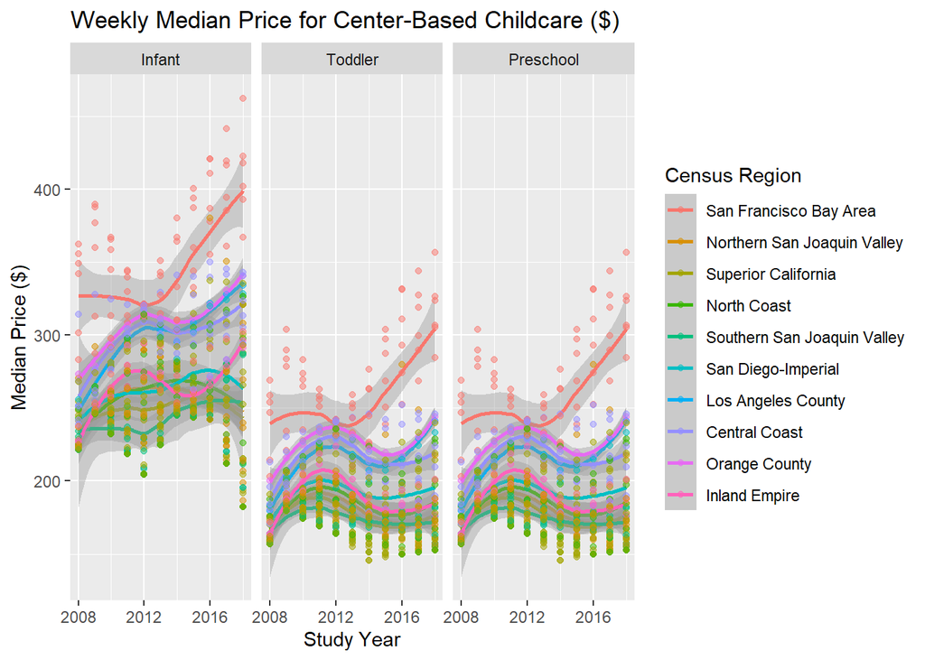

```r
ggplot(data = ca_childcare_transformed, mapping = aes(x = study_year, y = median_price, color = census_region)) +
  geom_smooth(method = "loess") +
  geom_point(alpha = .5) +
  facet_wrap(~ childcare_type) +
  labs(title = "Weekly Median Price for Center-Based Childcare ($)",
       x = "Study Year",
       y = "Median Price ($)",
       color = "Census Region") +
  scale_x_continuous(breaks = seq(2008, 2018, by = 4))
```

## Median Household Income vs. Childcare Costs for Infants

**7. Create a scatterplot showing the relationship between median household income (expressed in 2018 dollars) and the full-time median weekly price charged for center-based childcare for an infant in California. Overlay a linear regression line (lm) to show the trend.**

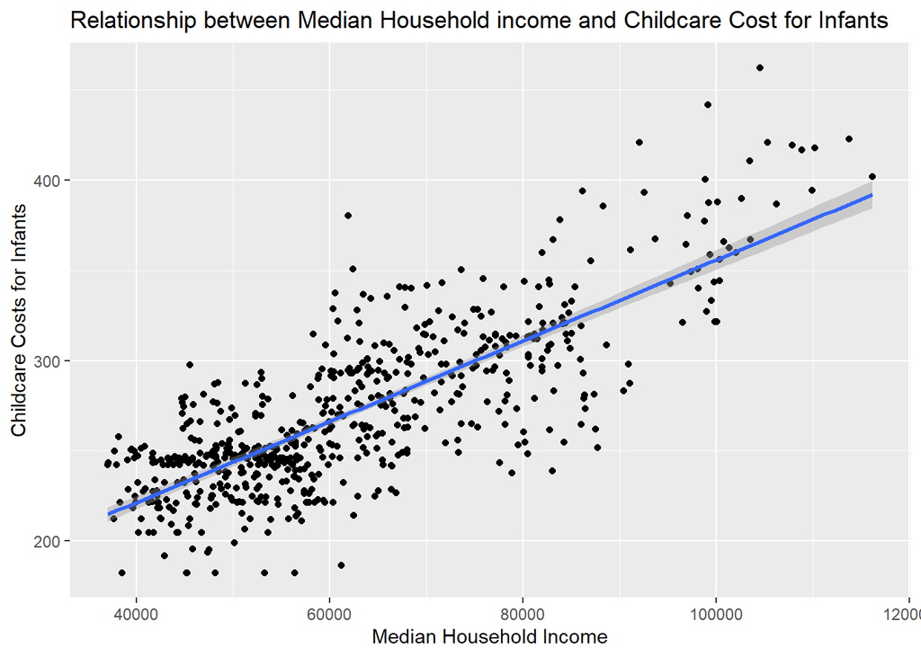

```r
ggplot(data = ca_childcare, mapping = aes(x = mhi_2018, y = mc_infant)) +
  geom_point() +
  geom_smooth(method="lm") +
  labs(title = "Relationship between Median Household income and Childcare Cost for Infants",
    x = "Median Household Income",
       y = "Childcare Costs for Infants")
```

**8. Look up the documentation for `lm()` and fit a linear regression model to the relationship shown in your plot above.**

```r
# complete the code provided
reg_mod1 <- lm(mhi_2018 ~ mc_infant, data = ca_childcare)
summary(reg_mod1)
```

```
Call:
lm(formula = mhi_2018 ~ mc_infant, data = ca_childcare)

Residuals:
     Min       1Q   Median       3Q      Max
-31249.3  -6853.2   -991.5   6277.1  31097.1

Coefficients:
             Estimate Std. Error t value Pr(>|t|)
(Intercept) -14669.86    2339.67   -6.27 6.66e-10 ***
mc_infant      283.37       8.52   33.26  < 2e-16 ***
---
Signif. codes:  0 '***' 0.001 '**' 0.01 '*' 0.05 '.' 0.1 ' ' 1

Residual standard error: 9772 on 636 degrees of freedom
Multiple R-squared:  0.635, Adjusted R-squared:  0.6344
F-statistic:  1106 on 1 and 636 DF,  p-value: < 2.2e-16
```

**9. Using the output from `summary()`, write out the estimated regression line (recall: $y = mx + b$).** y = 283.37x -14669.86

**10. Do you have evidence to conclude there is a relationship between the median household income and the median weekly cost of center-based childcare for infants in California? Cite values from your `summary()` output to support your claim!** Yes there is evidence to conclude there is a relationship between the median household income and the median weekly cost of center-based childcare for infants in California. The p-value is basically 0 means we can reject the null hypothesis that there is no relationship. R-square of .63 shows a strong positive relationship.